# Chapter 10 What are the differences at FMT1 between groups?

## 10.1 Is the GM of the intervention group more similar to warm population after one week from FMT?

### 10.1.1 Shapiro test

```r
alpha_div %>%
  pivot_longer(-sample, names_to = "metric", values_to = "value") %>%
  left_join(., sample_metadata, by = join_by(sample == Tube_code)) %>%
  filter(time_point =="FMT1") %>%
  filter(metric=="richness") %>%
  summarize(shapiro_p_value = shapiro.test(value)$p.value) %>%
  pull(shapiro_p_value)
```

```
[1] 0.6077531
```

```r
alpha_div %>%
  pivot_longer(-sample, names_to = "metric", values_to = "value") %>%
  left_join(., sample_metadata, by = join_by(sample == Tube_code)) %>%
  filter(time_point =="FMT1") %>%
  filter(metric=="neutral") %>%
  summarize(shapiro_p_value = shapiro.test(value)$p.value) %>%
  pull(shapiro_p_value)
```

```
[1] 0.3357428
```

```r
alpha_div %>%
  pivot_longer(-sample, names_to = "metric", values_to = "value") %>%
  left_join(., sample_metadata, by = join_by(sample == Tube_code)) %>%
  filter(time_point =="FMT1") %>%
  filter(metric=="phylogenetic") %>%
  summarize(shapiro_p_value = shapiro.test(value)$p.value) %>%
  pull(shapiro_p_value)
```

```
[1] 0.9273925
```

### 10.1.2 Alpha diversity

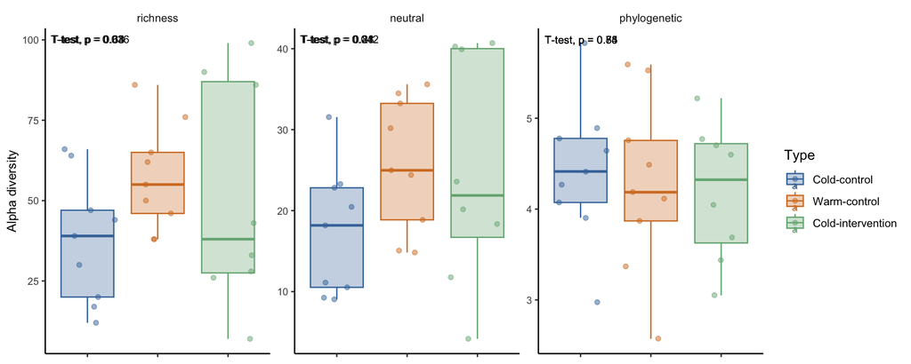

```r
alpha_div %>%
  pivot_longer(-sample, names_to = "metric", values_to = "value") %>%
  left_join(., sample_metadata, by = join_by(sample == Tube_code)) %>%
  filter(time_point=="FMT1") %>%
  mutate(metric=factor(metric,levels=c("richness","neutral","phylogenetic"))) %>%
      ggplot(aes(y = value, x = type, group=type, color=type, fill=type)) +
      geom_boxplot(outlier.shape = NA) +
      geom_jitter(alpha=0.5) +
      scale_color_manual(name="Type",
          breaks=c("Control","Hot_control", "Treatment"),
          labels=c("Cold-control","Warm-control", "Cold-intervention"),
          values=c("#4477AA","#d57d2c", "#76b183")) +
      scale_fill_manual(name="Type",
          breaks=c("Control","Hot_control", "Treatment"),
          labels=c("Cold-control","Warm-control", "Cold-intervention"),
          values=c("#4477AA50","#d57d2c50","#76b18350")) +
      facet_wrap(. ~ metric,scales = "free") +
      coord_cartesian(xlim = c(1, NA)) +
      stat_compare_means(method="t.test",size=3, label.x=.7) +
      theme_classic() +
        theme(
    strip.background = element_blank(),
    panel.grid.minor.x = element_line(size = .1, color = "grey"),
    axis.title.x = element_blank(),
    axis.title.y = element_text(size=10),
    axis.text.x = element_blank(),
    # Increase plot size
    plot.title = element_text(size = 10),
    axis.text = element_text(size = 8),
    axis.title = element_text(size = 8)
      ) +
  ylab("Alpha diversity")
```

***p<0.05 when comparing neutral beta diversity between Cold-control and Warm-control

### 10.1.3 Beta diversity

*Number of samples used*

```r
samples_to_keep_post1 <- sample_metadata %>%
  filter(time_point == "FMT1") %>%
  select(Tube_code) %>%
  pull()
subset_meta_post1 <- sample_metadata %>%
  filter(time_point == "FMT1")
length(samples_to_keep_post1)
```

```
[1] 26
```

*Richness*

```r
richness_post1 <- as.matrix(beta_q0n$S)
richness_post1 <- as.dist(richness_post1[rownames(richness_post1) %in% samples_to_keep_post1,
               colnames(richness_post1) %in% samples_to_keep_post1])
betadisper(richness_post1, subset_meta_post1$type) %>% permutest(., pairwise = TRUE)
```

```
Permutation test for homogeneity of multivariate dispersions
Permutation: free
Number of permutations: 999

Response: Distances
          Df  Sum Sq   Mean Sq      F N.Perm Pr(>F)
Groups     2 0.01060 0.0052999 1.1619    999   0.38
Residuals 23 0.10491 0.0045613

Pairwise comparisons:
(Observed p-value below diagonal, permuted p-value above diagonal)
             Control Hot_control Treatment
Control                 0.036000     0.641
Hot_control 0.055742                 0.478
Treatment   0.625388    0.420078
```

```r
adonis2(richness_post1 ~ type,
        data = subset_meta_post1 %>% arrange(match(Tube_code,labels(richness_post1))),
        permutations = 999) %>%
        broom::tidy() %>%
        tt()
```

| term | df | SumOfSqs | R2 | statistic | p.value |
| --- | --- | --- | --- | --- | --- |
| Model | 2 | 1.195567 | 0.1448246 | 1.947534 | 0.001 |
| Residual | 23 | 7.059710 | 0.8551754 | NA | NA |
| Total | 25 | 8.255277 | 1.0000000 | NA | NA |

```r
subset_meta_post1_arrange <- column_to_rownames(subset_meta_post1, "Tube_code")
subset_meta_post1_arrange<-subset_meta_post1_arrange[labels(richness_post1),]

pairwise <- pairwise.adonis(richness_post1, subset_meta_post1_arrange$type, perm=999)
pairwise%>%
  tt()
```

| pairs | Df | SumsOfSqs | F.Model | R2 | p.value | p.adjusted | sig |
| --- | --- | --- | --- | --- | --- | --- | --- |
| Control vs Treatment | 1 | 0.5615418 | 1.729004 | 0.1033537 | 0.014 | 0.042 | . |
| Control vs Hot_control | 1 | 0.8438429 | 2.793772 | 0.1486541 | 0.001 | 0.003 | * |
| Treatment vs Hot_control | 1 | 0.3734921 | 1.268929 | 0.0779971 | 0.102 | 0.306 |  |

*Neutral*

```r
neutral_post1 <- as.matrix(beta_q1n$S)
neutral_post1 <- as.dist(neutral_post1[rownames(neutral_post1) %in% samples_to_keep_post1,
               colnames(neutral_post1) %in% samples_to_keep_post1])
betadisper(neutral_post1, subset_meta_post1$type) %>% permutest(., pairwise = TRUE)
```

```
Permutation test for homogeneity of multivariate dispersions
Permutation: free
Number of permutations: 999

Response: Distances
          Df   Sum Sq   Mean Sq      F N.Perm Pr(>F)
Groups     2 0.002996 0.0014982 0.1374    999  0.881
Residuals 23 0.250747 0.0109020

Pairwise comparisons:
(Observed p-value below diagonal, permuted p-value above diagonal)
            Control Hot_control Treatment
Control                 0.55200     0.892
Hot_control 0.55320                 0.748
Treatment   0.86589     0.76648
```

```r
adonis2(neutral_post1 ~ type,
        data = subset_meta_post1 %>% arrange(match(Tube_code,labels(neutral_post1))),
        permutations = 999) %>%
        broom::tidy() %>%
        tt()
```

| term | df | SumOfSqs | R2 | statistic | p.value |
| --- | --- | --- | --- | --- | --- |
| Model | 2 | 1.395968 | 0.1900228 | 2.697931 | 0.001 |
| Residual | 23 | 5.950350 | 0.8099772 | NA | NA |
| Total | 25 | 7.346318 | 1.0000000 | NA | NA |

```r
subset_meta_post1_arrange <- column_to_rownames(subset_meta_post1, "Tube_code")
subset_meta_post1_arrange<-subset_meta_post1_arrange[labels(neutral_post1),]
pairwise <- pairwise.adonis(neutral_post1, subset_meta_post1_arrange$type, perm=999)
pairwise%>%
  tt()
```

| pairs | Df | SumsOfSqs | F.Model | R2 | p.value | p.adjusted | sig |
| --- | --- | --- | --- | --- | --- | --- | --- |
| Control vs Treatment | 1 | 0.6051778 | 2.250849 | 0.13047758 | 0.013 | 0.039 | . |
| Control vs Hot_control | 1 | 1.0528902 | 4.143637 | 0.20570451 | 0.001 | 0.003 | * |
| Treatment vs Hot_control | 1 | 0.4150076 | 1.637268 | 0.09840968 | 0.058 | 0.174 |  |

*Phylogenetic*

```r
phylo_post1 <- as.matrix(beta_q1p$S)
phylo_post1 <- as.dist(phylo_post1[rownames(phylo_post1) %in% samples_to_keep_post1,
               colnames(phylo_post1) %in% samples_to_keep_post1])
betadisper(phylo_post1, subset_meta_post1$type) %>% permutest(., pairwise = TRUE)
```

```
Permutation test for homogeneity of multivariate dispersions
Permutation: free
Number of permutations: 999

Response: Distances
          Df  Sum Sq   Mean Sq      F N.Perm Pr(>F)
Groups     2 0.00399 0.0019943 0.1213    999  0.923
Residuals 23 0.37812 0.0164399

Pairwise comparisons:
(Observed p-value below diagonal, permuted p-value above diagonal)
            Control Hot_control Treatment
Control                 0.91000     0.716
Hot_control 0.91065                 0.802
Treatment   0.65272     0.74852
```

```r
adonis2(phylo_post1 ~ type,
        data = subset_meta_post1 %>% arrange(match(Tube_code,labels(phylo_post1))),
        permutations = 999) %>%
        broom::tidy() %>%
        tt()
```

| term | df | SumOfSqs | R2 | statistic | p.value |
| --- | --- | --- | --- | --- | --- |
| Model | 2 | 0.07451036 | 0.07059466 | 0.8735033 | 0.554 |
| Residual | 23 | 0.98095695 | 0.92940534 | NA | NA |
| Total | 25 | 1.05546731 | 1.00000000 | NA | NA |

```r
subset_meta_post1_arrange <- column_to_rownames(subset_meta_post1, "Tube_code")
subset_meta_post1_arrange<-subset_meta_post1_arrange[labels(phylo_post1),]
pairwise <- pairwise.adonis(phylo_post1, subset_meta_post1_arrange$type, perm=999)
pairwise%>%
  tt()
```

| pairs | Df | SumsOfSqs | F.Model | R2 | p.value | p.adjusted | sig |
| --- | --- | --- | --- | --- | --- | --- | --- |
| Control vs Treatment | 1 | 0.01842535 | 0.4144162 | 0.02688498 | 0.766 | 1.000 |  |
| Control vs Hot_control | 1 | 0.05987967 | 1.7387847 | 0.09802164 | 0.102 | 0.306 |  |
| Treatment vs Hot_control | 1 | 0.03212966 | 0.6477782 | 0.04139746 | 0.695 | 1.000 |  |

*NMDS*

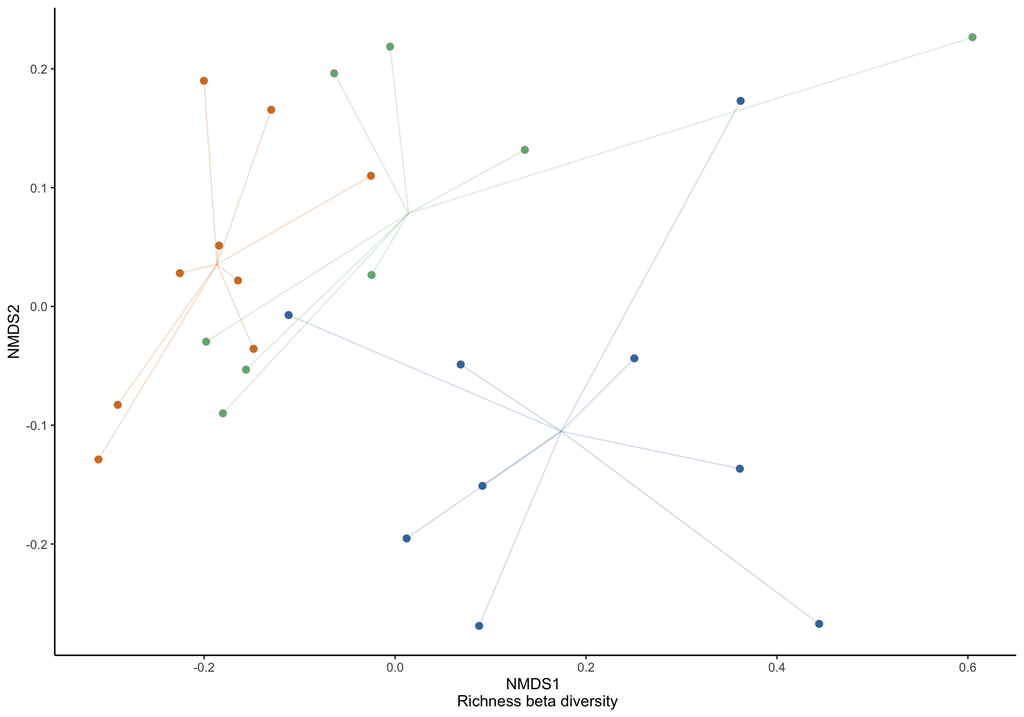

```r
richness_post1 %>%
                metaMDS(.,trymax = 500, k=2, verbosity=FALSE, trace = FALSE) %>%
                scores() %>%
                as_tibble(., rownames = "sample") %>%
                left_join(subset_meta_post1, by = join_by(sample == Tube_code)) %>%
            group_by(type) %>%
            mutate(x_cen = mean(NMDS1, na.rm = TRUE)) %>%
            mutate(y_cen = mean(NMDS2, na.rm = TRUE)) %>%
            ungroup() %>%
            ggplot(., aes(x=NMDS1,y=NMDS2, color=type)) +
        scale_color_manual(name="Type",
                       breaks=c("Control", "Hot_control", "Treatment"),
                       labels=c("Cold-Cold", "Hot-Hot", "Cold-Hot"),
                       values=c("#4477AA","#d57d2c","#76b183")) +
                geom_point(size=2) +
                geom_segment(aes(x=x_cen, y=y_cen, xend=NMDS1, yend=NMDS2), alpha=0.2) +
        labs(y = "NMDS2", x="NMDS1 \n Richness beta diversity") +
                theme_classic() +
                theme(legend.position="none")
```

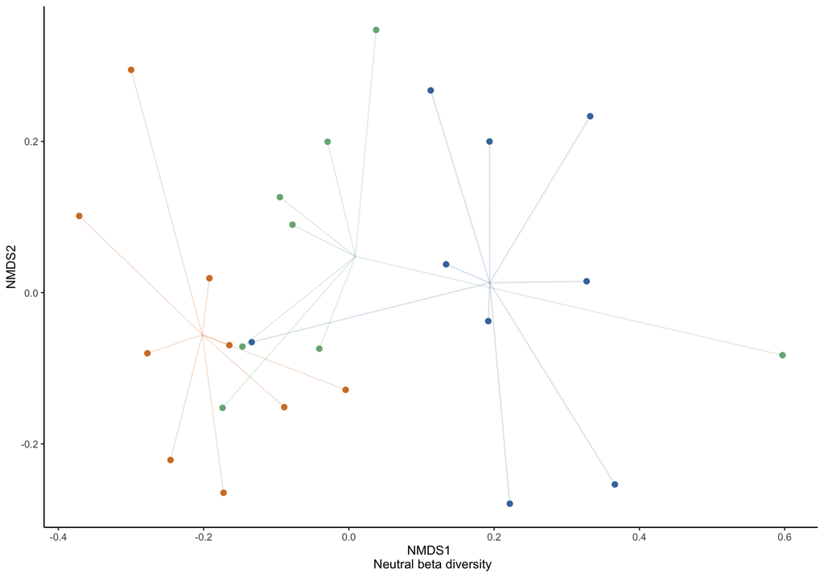

```r
neutral_post1 %>%
                metaMDS(.,trymax = 500, k=2, verbosity=FALSE, trace = FALSE) %>%
                scores() %>%
                as_tibble(., rownames = "sample") %>%
                left_join(subset_meta_post1, by = join_by(sample == Tube_code))%>%
            group_by(type) %>%
            mutate(x_cen = mean(NMDS1, na.rm = TRUE)) %>%
            mutate(y_cen = mean(NMDS2, na.rm = TRUE)) %>%
            ungroup() %>%
            ggplot(., aes(x=NMDS1,y=NMDS2, color=type)) +
        scale_color_manual(name="Type",
                       breaks=c("Control", "Hot_control", "Treatment"),
                       labels=c("Cold-Cold", "Hot-Hot", "Cold-Hot"),
                       values=c("#4477AA","#d57d2c","#76b183")) +
                geom_point(size=2) +
                geom_segment(aes(x=x_cen, y=y_cen, xend=NMDS1, yend=NMDS2), alpha=0.2) +
        labs(y = "NMDS2", x="NMDS1 \n Neutral beta diversity") +
                theme_classic() +
                theme(legend.position="none")
```

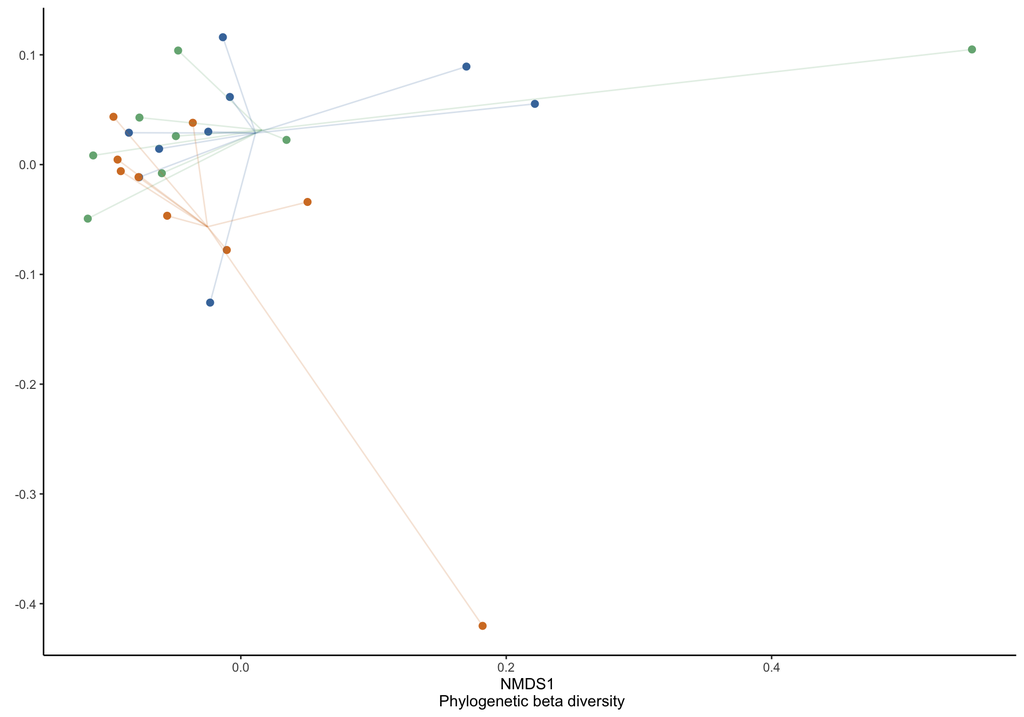

```r
phylo_post1 %>%
                metaMDS(.,trymax = 500, k=2, verbosity=FALSE, trace = FALSE) %>%
                scores() %>%
                as_tibble(., rownames = "sample") %>%
                left_join(subset_meta_post1, by = join_by(sample == Tube_code))%>%
            group_by(type) %>%
            mutate(x_cen = mean(NMDS1, na.rm = TRUE)) %>%
            mutate(y_cen = mean(NMDS2, na.rm = TRUE)) %>%
            ungroup() %>%
            ggplot(., aes(x=NMDS1,y=NMDS2, color=type)) +
                scale_color_manual(name="Type",
                       breaks=c("Control", "Hot_control", "Treatment"),
                       labels=c("Cold-Cold", "Hot-Hot", "Cold-Hot"),
                       values=c("#4477AA","#d57d2c","#76b183")) +
                geom_point(size=2) +
                geom_segment(aes(x=x_cen, y=y_cen, xend=NMDS1, yend=NMDS2), alpha=0.2) +
        labs(y= element_blank (), x="NMDS1 \n Phylogenetic beta diversity") +
                theme_classic() +
                theme(legend.position="none")
```

### 10.1.4 Differentially abundant MAGs

#### 10.1.4.1 Warm vs Intervention

*Structural zeros*

```r
struc <- structural_zeros %>%
  filter(present=="warm_control")%>%
  count(phylum, name = "Hot_control") %>%
  arrange(desc(Hot_control))
structural_zeros %>%
  filter(present=="treatment")%>%
  count(phylum, name = "Treatment") %>%
  arrange(desc(Treatment)) %>%
  full_join(., struc, by="phylum") %>%
  mutate(across(everything(), ~ ifelse(is.na(.), 0, .))) %>%
  tt()
```

| phylum | Treatment | Hot_control |
| --- | --- | --- |
| p__Bacillota_A | 9 | 12 |
| p__Bacteroidota | 8 | 5 |
| p__Bacillota | 3 | 9 |
| p__Desulfobacterota | 2 | 1 |
| p__Actinomycetota | 1 | 1 |
| p__Campylobacterota | 1 | 0 |
| p__Cyanobacteriota | 1 | 4 |
| p__Verrucomicrobiota | 1 | 0 |
| p__Pseudomonadota | 0 | 5 |
| p__Bacillota_C | 0 | 2 |
| p__Bacillota_B | 0 | 1 |
| p__Chlamydiota | 0 | 1 |
| p__Spirochaetota | 0 | 1 |

```r
physeq_FMT1 <- subset_samples(physeq_all, type %in% c("Hot_control", "Treatment") & time_point == "FMT1")
physeq_FMT1 <- prune_taxa(taxa_sums(physeq_FMT1)>0, physeq_FMT1)
```

```r
ancom_rand_output_fmt1 = ancombc2(data = physeq_FMT1,
                  assay_name = "counts",
                  tax_level = NULL,
                  fix_formula = "type",
                  p_adj_method = "holm",
                  pseudo_sens = TRUE,
                  prv_cut =0,
                  lib_cut = 0,
                  s0_perc = 0.05,
                  group = NULL,
                  struc_zero = FALSE,
                  neg_lb = FALSE,
                  alpha = 0.05,
                  n_cl = 2,
                  verbose = TRUE,
                  global = FALSE,
                  pairwise = FALSE,
                  dunnet = FALSE,
                  trend = FALSE,
                  iter_control = list(tol = 1e-5, max_iter = 20, verbose = FALSE),
                  em_control = list(tol = 1e-5, max_iter = 100),
                  mdfdr_control = list(fwer_ctrl_method = "holm", B = 100),
                  trend_control = NULL)
```

```r
save(ancom_rand_output_fmt1, file="data/ancom_rand_output_fmt1.RData")
```

```r
load("data/ancom_rand_output_fmt1.RData")
```

```r
ancom_rand_output_fmt1$res %>%
  dplyr::select(taxon, lfc_typeTreatment, p_typeTreatment) %>%
  filter(p_typeTreatment < 0.05)
```

```
                   taxon lfc_typeTreatment p_typeTreatment
1   AH1_2nd_2:bin_000001         1.5624677     0.018919780
2  AH1_2nd_16:bin_000020         1.2543468     0.021313464
3   AH1_2nd_8:bin_000006        -1.4308506     0.038167012
4   AH1_2nd_1:bin_000023         1.6503345     0.002555181
5  AH1_2nd_16:bin_000058         1.3473611     0.022667050
6   AH1_2nd_2:bin_000017         1.7705419     0.025232075
7   LI1_2nd_8:bin_000019        -2.1022782     0.011143033
8   AH1_2nd_1:bin_000048         0.8195104     0.036621153
9   AH1_2nd_5:bin_000006         1.8686151     0.013960894
10 AH1_2nd_20:bin_000016        -1.4853429     0.017176614
11  LI1_2nd_4:bin_000003        -1.6188761     0.003401341
12 AH1_2nd_20:bin_000073        -1.9847277     0.049679526
```

```r
taxonomy <- data.frame(physeq_FMT1@tax_table) %>%
  rownames_to_column(., "taxon") %>%
  mutate_at(vars(order, phylum, family, genus, species), ~ str_replace(., "[dpcofgs]__", ""))

ancombc_rand_table_mag <- ancom_rand_output_fmt1$res %>%
  dplyr::select(taxon, lfc_typeTreatment, p_typeTreatment) %>%
  #filter(p_typeTreatment < 0.05) %>%
  dplyr::arrange(p_typeTreatment) %>%
  merge(., taxonomy, by="taxon") %>%
  mutate_at(vars(phylum, species), ~ str_replace(., "[dpcofgs]__", ""))%>%
  dplyr::arrange(lfc_typeTreatment)

ancombc_rand_table_mag
```

```
                    taxon lfc_typeTreatment p_typeTreatment      domain           phylum                  class               order               family                genus                      species
1   AH1_2nd_18:bin_000011      -2.468619132     1.000000000 d__Bacteria        Bacillota             c__Bacilli  Erysipelotrichales     Coprobacillaceae        Coprobacillus
2    LI1_2nd_8:bin_000019      -2.102278206     0.011143033 d__Bacteria      Bacillota_A          c__Clostridia  Christensenellales              UBA3700
3    AH1_2nd_7:bin_000028      -2.066980233     1.000000000 d__Bacteria Campylobacterota     c__Campylobacteria   Campylobacterales    Helicobacteraceae               NHYM01
4   AH1_2nd_20:bin_000040      -2.016595193     1.000000000 d__Bacteria Desulfobacterota    c__Desulfovibrionia  Desulfovibrionales  Desulfovibrionaceae            Bilophila        Bilophila wadsworthia
5   AH1_2nd_20:bin_000073      -1.984727713     0.049679526 d__Bacteria        Bacillota             c__Bacilli     Lactobacillales      Enterococcaceae         Enterococcus     Enterococcus sp002174455
6    LI1_2nd_9:bin_000007      -1.739676190     0.050274812 d__Bacteria   Pseudomonadota c__Alphaproteobacteria                RF32              CAG-239             CAJLXD01
7    LI1_2nd_4:bin_000003      -1.618876088     0.003401341 d__Bacteria        Bacillota             c__Bacilli  Erysipelotrichales  Erysipelotrichaceae               Dielma
8   AH1_2nd_20:bin_000016      -1.485342916     0.017176614 d__Bacteria        Bacillota             c__Bacilli  Erysipelotrichales  Erysipelotrichaceae
9    AH1_2nd_8:bin_000006      -1.430850620     0.038167012 d__Bacteria      Bacillota_A          c__Clostridia      Lachnospirales      Lachnospiraceae               CAG-95
10   LI1_2nd_4:bin_000035      -1.302384706     0.077504423 d__Bacteria     Bacteroidota         c__Bacteroidia       Bacteroidales       Bacteroidaceae          Bacteroides      Bacteroides sp900552405
11   LI1_2nd_4:bin_000052      -1.095822609     1.000000000 d__Bacteria      Bacillota_A          c__Clostridia      Lachnospirales      Lachnospiraceae        Enterocloster
12  AH1_2nd_20:bin_000008      -1.080863538     1.000000000 d__Bacteria     Bacteroidota         c__Bacteroidia       Bacteroidales        Rikenellaceae            Alistipes
13  AH1_2nd_14:bin_000015      -0.972644946     1.000000000 d__Bacteria      Bacillota_A          c__Clostridia  Christensenellales              UBA3700
14   AH1_2nd_6:bin_000037      -0.966615209     1.000000000 d__Bacteria     Bacteroidota         c__Bacteroidia       Bacteroidales               UBA932          Egerieousia
```

[output cut: 87 more lines]

```r
colors_alphabetic <- read_tsv("https://raw.githubusercontent.com/earthhologenome/EHI_taxonomy_colour/main/ehi_phylum_colors.tsv") %>%
  mutate_at(vars(phylum), ~ str_replace(., "[dpcofgs]__", ""))  %>%
  right_join(taxonomy, by=join_by(phylum == phylum)) %>%
  dplyr::select(phylum, colors) %>%
  mutate(colors = str_c(colors, "80"))  %>% #add 80% alpha
    unique() %>%
    dplyr::arrange(phylum)

tax_table <- as.data.frame(unique(ancombc_rand_table_mag$phylum))

colnames(tax_table)[1] <- "phylum"
tax_color <- merge(tax_table, colors_alphabetic, by="phylum")%>%
    dplyr::arrange(phylum) %>%
    dplyr::select(colors) %>%
    pull()
```

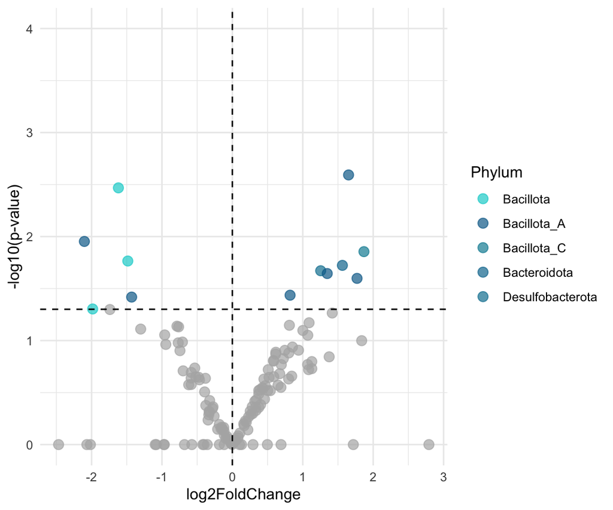

```r
ancombc_rand_table_mag %>%
  mutate(
    genome = factor(taxon, levels = ancombc_rand_table_mag$taxon),
    significance = ifelse(p_typeTreatment < 0.05, phylum, NA)  # Set non-significant to NA (not mapped in legend)
  ) %>%
  ggplot() +
  # Plot significant points with legend
  geom_point(aes(x = lfc_typeTreatment, y = -log10(p_typeTreatment), color = significance),
             size = 3, alpha = 0.7, na.rm = TRUE) +
  # Plot non-significant points separately without legend
  geom_point(data = filter(ancombc_rand_table_mag, p_typeTreatment >= 0.05),
             aes(x = lfc_typeTreatment, y = -log10(p_typeTreatment)),
             color = "grey70", size = 3, alpha = 0.7, show.legend = FALSE) +
  scale_color_manual(
    values = tax_color,  # Only keeps phylum colors in legend
    na.translate = FALSE  # Removes NA (non-significant) from legend
  ) +
  geom_hline(yintercept = -log10(0.05), linetype = "dashed") +
  geom_vline(xintercept = 0, linetype = "dashed") +
  scale_y_continuous(limits = c(0, 4)) +
  xlab("log2FoldChange") +
  ylab("-log10(p-value)") +
  guides(color = guide_legend(title = "Phylum")) +
  theme_minimal()+
  annotate("text", x = min(ancombc_rand_table_mag$lfc_typeTreatment), y = 4,
           label = "Cold-intervention", hjust = 0, size = 4, fontface = "bold") +
  annotate("text", x = max(ancombc_rand_table_mag$lfc_typeTreatment), y = 4,
           label = "Warm-control", hjust = 1, size = 4, fontface = "bold")
```

*Phyla of the significant MAGs in warm control*

```r
ancombc_rand_table_mag%>%
  filter(p_typeTreatment < 0.05) %>%
  filter(lfc_typeTreatment>0)  %>%
  count(phylum, name = "sample_count") %>%
  arrange(desc(sample_count))
```

```
            phylum sample_count
1      Bacillota_A            4
2      Bacillota_C            1
3     Bacteroidota            1
4 Desulfobacterota            1
```

*Phyla of the significant MAGs in intervention group*

```r
ancombc_rand_table_mag%>%
  filter(p_typeTreatment < 0.05) %>%
  filter(lfc_typeTreatment<0)  %>%
  count(phylum, name = "sample_count") %>%
  arrange(desc(sample_count))
```

```
       phylum sample_count
1   Bacillota            3
2 Bacillota_A            2
```

#### 10.1.4.2 Intervention vs cold control

*Structural zeros*

```r
struc <- structural_zeros %>%
  filter(present=="cold_control")%>%
  count(phylum, name = "Cold_control") %>%
  arrange(desc(Cold_control))
structural_zeros %>%
  filter(present=="treatment")%>%
  count(phylum, name = "Treatment") %>%
  arrange(desc(Treatment)) %>%
  full_join(., struc, by="phylum") %>%
  mutate(across(everything(), ~ ifelse(is.na(.), 0, .))) %>%
  tt()
```

| phylum | Treatment | Cold_control |
| --- | --- | --- |
| p__Bacteroidota | 24 | 10 |
| p__Bacillota_A | 16 | 4 |
| p__Desulfobacterota | 3 | 3 |
| p__Bacillota | 2 | 3 |
| p__Campylobacterota | 2 | 0 |
| p__Cyanobacteriota | 2 | 2 |
| p__Bacillota_C | 1 | 2 |
| p__Elusimicrobiota | 1 | 0 |
| p__Pseudomonadota | 1 | 4 |
| p__Actinomycetota | 0 | 1 |
| p__Chlamydiota | 0 | 1 |

```r
physeq_FMT1_cold <- subset_samples(physeq_all, type %in% c("Control", "Treatment") & time_point == "FMT1")
physeq_FMT1_cold <- prune_taxa(taxa_sums(physeq_FMT1_cold)>0, physeq_FMT1_cold)
```

```r
ancom_rand_output_cold = ancombc2(data = physeq_FMT1_cold,
                  assay_name = "counts",
                  tax_level = NULL,
                  fix_formula = "type",
                  p_adj_method = "holm",
                  pseudo_sens = TRUE,
                  prv_cut =0,
                  lib_cut = 0,
                  s0_perc = 0.05,
                  group = NULL,
                  struc_zero = FALSE,
                  neg_lb = FALSE,
                  alpha = 0.05,
                  n_cl = 2,
                  verbose = TRUE,
                  global = FALSE,
                  pairwise = FALSE,
                  dunnet = FALSE,
                  trend = FALSE,
                  iter_control = list(tol = 1e-5, max_iter = 20, verbose = FALSE),
                  em_control = list(tol = 1e-5, max_iter = 100),
                  mdfdr_control = list(fwer_ctrl_method = "holm", B = 100),
                  trend_control = NULL)
```

```r
save(ancom_rand_output_cold, file="data/ancom_rand_output_cold.RData")
```

```r
load("data/ancom_rand_output_cold.RData")
```

```r
ancom_rand_output_cold$res %>%
  dplyr::select(taxon, lfc_typeTreatment, p_typeTreatment) %>%
  filter(p_typeTreatment < 0.05) %>%
  left_join(., genome_metadata, by=join_by("taxon"=="genome")) %>%
  select(2,3,8,9,10) %>%
  tt()
```

| lfc_typeTreatment | p_typeTreatment | family | genus | species |
| --- | --- | --- | --- | --- |
| -1.2669085 | 0.016056297 | f__Bacteroidaceae | g__Bacteroides | s__ |
| -1.0321400 | 0.038302393 | f__Bacteroidaceae | g__Bacteroides | s__ |
| -0.9895362 | 0.028180996 | f__Tannerellaceae | g__Parabacteroides | s__ |
| -1.5258430 | 0.008367883 | f__Tannerellaceae | g__Parabacteroides | s__ |
| -1.5870692 | 0.009614235 | f__Enterobacteriaceae | g__Proteus | s__Proteus cibarius |
| -0.9815246 | 0.034489041 | f__Oscillospiraceae | g__Intestinimonas | s__ |
| -1.3260451 | 0.031388530 | f__Lachnospiraceae | g__JALFVM01 | s__ |
| -1.2001345 | 0.030460336 | f__Lachnospiraceae | g__Ventrimonas | s__ |
| -1.7676743 | 0.021740985 | f__UBA3700 | g__ | s__ |
| -0.9341728 | 0.023128929 | f__Mycoplasmoidaceae | g__Ureaplasma | s__ |
| 1.3651254 | 0.049425233 | f__Enterococcaceae | g__Enterococcus | s__Enterococcus sp002174455 |

```r
taxonomy <- data.frame(physeq_FMT1_cold@tax_table) %>%
  rownames_to_column(., "taxon") %>%
  mutate_at(vars(order, phylum, family, genus, species), ~ str_replace(., "[dpcofgs]__", ""))

ancombc_rand_table_mag <- ancom_rand_output_cold$res %>%
  dplyr::select(taxon, lfc_typeTreatment, p_typeTreatment) %>%
  #filter(p_typeTreatment < 0.05) %>%
  dplyr::arrange(p_typeTreatment) %>%
  merge(., taxonomy, by="taxon") %>%
  mutate_at(vars(phylum, species), ~ str_replace(., "[dpcofgs]__", ""))%>%
  dplyr::arrange(lfc_typeTreatment)

colors_alphabetic <- read_tsv("https://raw.githubusercontent.com/earthhologenome/EHI_taxonomy_colour/main/ehi_phylum_colors.tsv") %>%
  mutate_at(vars(phylum), ~ str_replace(., "[dpcofgs]__", ""))  %>%
  right_join(taxonomy, by=join_by(phylum == phylum)) %>%
  dplyr::select(phylum, colors) %>%
  mutate(colors = str_c(colors, "80"))  %>% #add 80% alpha
    unique() %>%
    dplyr::arrange(phylum)

tax_table <- as.data.frame(unique(ancombc_rand_table_mag$phylum))

colnames(tax_table)[1] <- "phylum"
tax_color <- merge(tax_table, colors_alphabetic, by="phylum")%>%
    dplyr::arrange(phylum) %>%
    dplyr::select(colors) %>%
    pull()
```

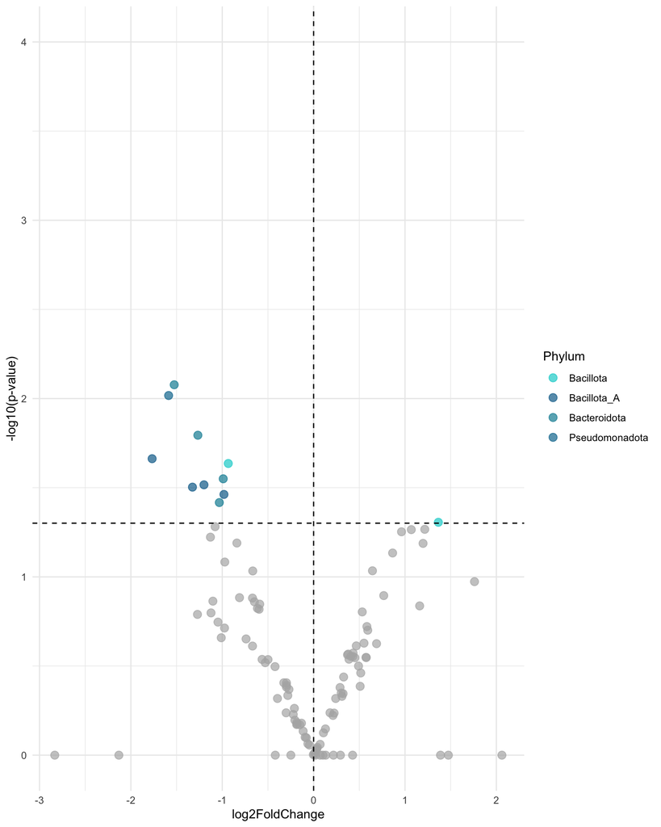

```r
ancombc_rand_table_mag %>%
  mutate(
    genome = factor(taxon, levels = ancombc_rand_table_mag$taxon),
    significance = ifelse(p_typeTreatment < 0.05, phylum, NA)  # Set non-significant to NA (not mapped in legend)
  ) %>%
  ggplot() +
  # Plot significant points with legend
  geom_point(aes(x = lfc_typeTreatment, y = -log10(p_typeTreatment), color = significance),
             size = 3, alpha = 0.7, na.rm = TRUE) +
  # Plot non-significant points separately without legend
  geom_point(data = filter(ancombc_rand_table_mag, p_typeTreatment >= 0.05),
             aes(x = lfc_typeTreatment, y = -log10(p_typeTreatment)),
             color = "grey70", size = 3, alpha = 0.7, show.legend = FALSE) +
  scale_color_manual(
    values = tax_color,  # Only keeps phylum colors in legend
    na.translate = FALSE  # Removes NA (non-significant) from legend
  ) +
  geom_hline(yintercept = -log10(0.05), linetype = "dashed") +
  geom_vline(xintercept = 0, linetype = "dashed") +
  scale_y_continuous(limits = c(0, 4)) +
  xlab("log2FoldChange") +
  ylab("-log10(p-value)") +
  guides(color = guide_legend(title = "Phylum")) +
  theme_minimal()+
  annotate("text", x = min(ancombc_rand_table_mag$lfc_typeTreatment), y = 4,
           label = "Cold-control", hjust = 0, size = 4, fontface = "bold") +
  annotate("text", x = max(ancombc_rand_table_mag$lfc_typeTreatment), y = 4,
           label = "Cold-intervention", hjust = 1, size = 4, fontface = "bold")
```

*Phyla of the significant MAGs in intervention group*

```r
ancombc_rand_table_mag%>%
  filter(p_typeTreatment < 0.05) %>%
  filter(lfc_typeTreatment>0)  %>%
  count(phylum, name = "sample_count") %>%
  arrange(desc(sample_count))
```

```
     phylum sample_count
1 Bacillota            1
```

*Phyla of the significant MAGs in cold control*

```r
ancombc_rand_table_mag%>%
  filter(p_typeTreatment < 0.05) %>%
  filter(lfc_typeTreatment<0)  %>%
  count(phylum, name = "sample_count") %>%
  arrange(desc(sample_count))
```

```
          phylum sample_count
1    Bacillota_A            4
2   Bacteroidota            4
3      Bacillota            1
4 Pseudomonadota            1
```

#### 10.1.4.3 Functional differences

*MCI*

```r
GIFTs_functions_community %>%
  rowMeans() %>%
  as_tibble(., rownames = "sample") %>%
  left_join(sample_metadata, by = join_by(sample == Tube_code)) %>%
  filter(time_point=="FMT1") %>%
  group_by(type) %>%
  summarise(MCI = mean(value), sd = sd(value))
```

```
# A tibble: 3 × 3
  type          MCI     sd
  <chr>       <dbl>  <dbl>
1 Control     0.373 0.0247
2 Hot_control 0.372 0.0367
3 Treatment   0.353 0.0186
```

```r
MCI_tm5_ele <- GIFTs_functions_community %>%
  rowMeans() %>%
  as_tibble(., rownames = "sample") %>%
  left_join(sample_metadata, by = join_by(sample == Tube_code)) %>%
  filter(time_point == "FMT1")

shapiro.test(MCI_tm5_ele$value)#normality test
```

```
    Shapiro-Wilk normality test

data:  MCI_tm5_ele$value
W = 0.92343, p-value = 0.05415
```

```r
res.aov <- aov(value ~ type, data = MCI_tm5_ele)#anova test
summary(res.aov)
```

```
            Df  Sum Sq   Mean Sq F value Pr(>F)
type         2 0.00216 0.0010798   1.371  0.274
Residuals   23 0.01811 0.0007875
```

*Functional differences*

CC and CI

```r
element_gift %>%
  filter(type %in% c("Control", "Treatment") & time_point == "FMT1") %>%
  select(-time_point, -type) %>%
  filter(rowSums(across(where(is.numeric), ~ . != 0)) > 0) %>%
  select(Tube_code, where( ~ is.numeric(.) && sum(.) > 0)) %>%
  left_join(sample_metadata[c(1, 7)], by = "Tube_code") %>%
  pivot_longer(-c(Tube_code, type),
               names_to = "trait",
               values_to = "value") %>%
  group_by(trait) %>%
  summarise(p_value = wilcox.test(value ~ type)$p.value) %>%
  mutate(p_adjust = p.adjust(p_value, method = "BH")) %>%
  filter(p_adjust < 0.05) %>%
  remove_rownames()
```

```
# A tibble: 0 × 3
# ℹ 3 variables: trait <chr>, p_value <dbl>, p_adjust <dbl>
```

CI and WC

```r
element_gift %>%
  filter(type %in% c("Hot_control", "Treatment") &
           time_point == "FMT1") %>%
  select(-time_point, -type) %>%
  filter(rowSums(across(where(is.numeric), ~ . != 0)) > 0) %>%
  select(Tube_code, where(~ is.numeric(.) && sum(.) > 0)) %>%
  left_join(sample_metadata[c(1, 7)], by = "Tube_code") %>%
  pivot_longer(-c(Tube_code,type), names_to = "trait", values_to = "value") %>%
  group_by(trait) %>%
  summarise(p_value = wilcox.test(value ~ type)$p.value) %>%
  mutate(p_adjust=p.adjust(p_value, method="BH")) %>%
  filter(p_adjust < 0.05)%>%
  remove_rownames()
```

```
# A tibble: 0 × 3
# ℹ 3 variables: trait <chr>, p_value <dbl>, p_adjust <dbl>
```

CC and WC

```r
element_gift %>%
  filter(type %in% c("Hot_control", "Control") &
           time_point == "FMT1") %>%
  select(-time_point, -type) %>%
  filter(rowSums(across(where(is.numeric), ~ . != 0)) > 0) %>%
  select(Tube_code, where(~ is.numeric(.) && sum(.) > 0)) %>%
  left_join(sample_metadata[c(1, 7)], by = "Tube_code") %>%
  pivot_longer(-c(Tube_code,type), names_to = "trait", values_to = "value") %>%
  group_by(trait) %>%
  summarise(p_value = wilcox.test(value ~ type)$p.value) %>%
  mutate(p_adjust=p.adjust(p_value, method="BH")) %>%
  filter(p_adjust < 0.05)%>%
  remove_rownames()
```

```
# A tibble: 0 × 3
# ℹ 3 variables: trait <chr>, p_value <dbl>, p_adjust <dbl>
```

### 10.2.1 Shapiro test

```r
alpha_div %>%
  pivot_longer(-sample, names_to = "metric", values_to = "value") %>%
  left_join(., sample_metadata, by = join_by(sample == Tube_code)) %>%
  filter(time_point =="FMT2") %>%
  filter(metric=="richness") %>%
  summarize(shapiro_p_value = shapiro.test(value)$p.value) %>%
  pull(shapiro_p_value)
```

```
[1] 0.1683943
```

```r
alpha_div %>%
  pivot_longer(-sample, names_to = "metric", values_to = "value") %>%
  left_join(., sample_metadata, by = join_by(sample == Tube_code)) %>%
  filter(time_point =="FMT2") %>%
  filter(metric=="neutral") %>%
  summarize(shapiro_p_value = shapiro.test(value)$p.value) %>%
  pull(shapiro_p_value)
```

```
[1] 0.6310339
```

```r
alpha_div %>%
  pivot_longer(-sample, names_to = "metric", values_to = "value") %>%
  left_join(., sample_metadata, by = join_by(sample == Tube_code)) %>%
  filter(time_point =="FMT2") %>%
  filter(metric=="phylogenetic") %>%
  summarize(shapiro_p_value = shapiro.test(value)$p.value) %>%
  pull(shapiro_p_value)
```

```
[1] 0.3446539
```

### 10.2.2 Alpha diversity

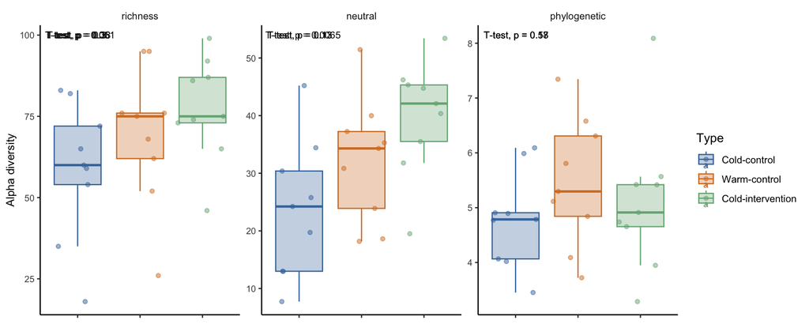

```r
alpha_div %>%
  pivot_longer(-sample, names_to = "metric", values_to = "value") %>%
  left_join(., sample_metadata, by = join_by(sample == Tube_code)) %>%
  filter(time_point=="FMT2") %>%
  mutate(metric=factor(metric,levels=c("richness","neutral","phylogenetic"))) %>%
      ggplot(aes(y = value, x = type, group=type, color=type, fill=type)) +
      geom_boxplot(outlier.shape = NA) +
      geom_jitter(alpha=0.5) +
      scale_color_manual(name="Type",
          breaks=c("Control","Hot_control", "Treatment"),
          labels=c("Cold-control","Warm-control", "Cold-intervention"),
          values=c("#4477AA","#d57d2c", "#76b183")) +
      scale_fill_manual(name="Type",
          breaks=c("Control","Hot_control", "Treatment"),
          labels=c("Cold-control","Warm-control", "Cold-intervention"),
          values=c("#4477AA50","#d57d2c50","#76b18350")) +
        scale_x_discrete(labels = c("Control" = "Cold-Cold", "Hot_control" = "Hot-Hot", "Treatment" = "Cold-Hot")) +
      facet_wrap(. ~ metric,scales = "free") +
      coord_cartesian(xlim = c(1, NA)) +
      stat_compare_means(method="t.test",size=3, label.x=.7) +
      theme_classic() +
        theme(
    strip.background = element_blank(),
    panel.grid.minor.x = element_line(size = .1, color = "grey"),
    axis.title.x = element_blank(),
    axis.title.y = element_text(size=10),
    axis.text.x = element_blank(),
    # Increase plot size
    plot.title = element_text(size = 10),
    axis.text = element_text(size = 8),
    axis.title = element_text(size = 8)
      ) +
  ylab("Alpha diversity")
```